# PEC

Gabriel Granda

2024-04-03

# Descripción del conjunto de datos

```r
# Librerías:

library(readr)
library(readxl)
library(dplyr)
library(ggplot2)
library(tidyverse)
library(DT)
library(corrplot)
library(caret)
library(fastDummies)
library(SHAPforxgboost)
# Datos:

insurance_claims <- read_csv("datos/insurance_claims.csv")

insurance_claims %>% nrow()
```

```
## [1] 1000
```

```r
insurance_claims %>% ncol()
```

```
## [1] 40
```

El conjunto de datos contiene 1000 registros y 40 variables sobre reclamos de seguros de automóviles, cada fila corresponde a un reclamo y las columnas a las características asociadas a este reclamo.

La variable principal es **fraud_reported**, que indica la legitimidad del reclamo. Corresponde a una variable binaria que indica si se ha reportado o no un fraude en relación con un reclamo de seguro de automóvil.

Se cuenta con las siguientes variables:

1. months_as_customer: Es una variable numérica que indica el número de meses que tiene el asegurador como cliente.
2. age: Variable numérica que indica la edad del cliente.
3. policy_number: Número de poliza.
4. policy_bind_date: Fecha de vinculación de la poliza.
5. policy_state: Estado en el que se emitió la poliza, toma los valores IL (Illinois), IN (Indiana), OH (Ohio).
6. policy_csl: Variable categórica, indica los límites de responsabilidad civil de una póliza de seguro de automóvil, se tienen las siguientes categorías 100/300, 250/500, 500/1000. Por ejemplo, la categoría 100/300 establece un límite de $100,000 para lesiones corporales por persona y $300,000 en total por accidente.
7. policy_deductable: Variable numérica, corresponde a la cantidad de dinero que el asegurado debe pagar de su propio bolsillo antes de que la compañía de seguros comience a cubrir los costos de un reclamo.
8. policy_annual_premium: Variable numérica, prima anual de la póliza de seguro. La prima es el monto de dinero que el asegurado paga a la compañía de seguros a cambio de la cobertura proporcionada por la póliza durante un período específico, que generalmente es de un año.
9. umbrella_limit: Variable numérica, corresponde al límite de la poliza de seguro de responsabilidad civil adicional que proporciona una protección extra de los límites estándar de la póliza.
10. insured_zip: Código Postal del asegurado.
11. insured_sex: Sexo del asegurado, toma los valores FEMALE, MALE.
12. insured_education_level: Variable categórica, nivel de educación del asegurado. Se tienen los siguientes niveles: Associate, College High School, JD, Masters, MD, PhD.
13. insured_occupation: Ocupación del asegurado, toma 14 valores distintos, por ejemplo, adm-clerical, armed-forces, craft-repair.
14. insured_hobbies: Pasatiempos del asegurado, toma 20 valores distintos, por ejemplo, base-jumping, basketball, board-game.
15. insured_relationship: Estado civil del asegurado, toma los valores: husband, not-in-family other-relative, own-child, unmarried, wife.
16. capital-gains: Ganancias del capital.
17. capital-loss: Pérdidas del capital.

    Las variables relativas al incidente son:
18. incident_date: Fecha en que ocurrió el incidente.
19. incident_type: Variable categórica que indica el tipo de incidente ocurrido, toma los valores: Multi-vehicle Collision, Parked Car Single Vehicle Collision, Vehicle Theft.
20. collision_type: Tipo de colisión que ocurrió en el accidente, toma los valores de “?”, Front Collision , Rear Collision, Side Collision. Notemos que se tiene el símbolo “?” posiblemente para denotar falta de información.
21. incident_severity: Variable categórica que indica el nivel de gravedad del incidente. Tiene las siguientes categorías Major Damage, Minor Damage, Total Loss, Trivial Damage.
22. authorities_contacted: Variable categórica que identifica el tipo de autoridad contactada. Por ejemplo, Ambulance, Fire, None, Other, Police.
23. incident_state: Estado donde ocurrió el accidente: NC, NY, OH, PA, SC, VA y WV.
24. incident_city: Ciudad donde ocurrió el incidente. Por ejemeplo, Arlington, Columbus, Hillsdale, Northbend, Northbrook, Riverwood, Springfield.
25. incident_location: Ubicación donde ocurrió el incidente o el accidente, se tienen 1000 valores distintos.
26. incident_hour_of_the_day: Variable numérica discreta que indica la hora del día en que ocurrió el incidente o el accidente.
27. number_of_vehicles_involved: Variable numérica discreta que indica el número de vehículos involucrados en el incidente o el accidente.
28. property_damage: Variable binaria que indica si existen daños o no a la propiedad externa como resultado del incidente o accidente.
29. bodily_injuries: Número total de lesiones reportadas como resultado del incidente o accidente de tránsito.
30. witnesses: Indica el número total de testigos presentes en el lugar del incidente o accidente.
31. police_report_available: Variable categórica que indica si existe o no un informe policial sobre el incidente o accidente.
32. total_claim_amount: Monto total reclamado por el asegurador como resultado del incidente o accidente.
33. injury_claim: Monto reclamado por lesiones como resultado del incidente o accidente.
34. property_claim: Monto reclamado por daños a la propiedad como resultado del incidente o accidente.
35. vehicle_claim: Monto reclamado específicamente por los daños al vehículo asegurado como resultado del accidente.
36. auto_make: Marca del Auto, se tiene 14 marcas distintas.
37. auto_model: Modelo del auto, se cuentan con 39 modelos distintos.
38. auto_year: Anio del vehículo.
39. fraud_reported: Variable binaria que indica si se ha reportado o no un fraude en relación con un reclamo de seguro de automóvil.
40. c_39: Variable que posee todos los valores en blanco.

# Análisis estadístico

Previo a realizar el análisis estadístico del conjunto de datos vamos a descartar las siguientes variables:

```r
insurance_claims<- insurance_claims %>% dplyr::select(-policy_number, -insured_zip,
                                                      -incident_location, -`_c39`)
```

## Variable objetivo

Ahora, vamos a estudiar la variable a modelar.

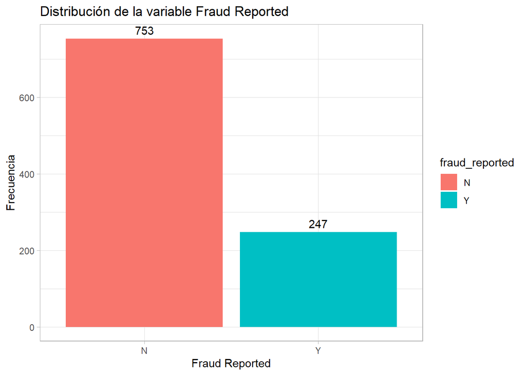

```r
ggplot(insurance_claims, aes(x = fraud_reported, fill = fraud_reported)) +
  geom_bar() +
  stat_count(geom = "text",
             aes(label = after_stat(count)),
             vjust = -.5)+
  labs(title = "Distribución de la variable Fraud Reported", x = "Fraud Reported", y = "Frecuencia") +
  theme_light()
```

```r
100*prop.table(table(insurance_claims$fraud_reported))
```

```
##
##    N    Y
## 75.3 24.7
```

De este modo, el 75.3% de los reclamos que se han reportado no corresponden a un fraude, mientras que el 24.7% si lo son. Por lo tanto, nuestra variable no está desbalanceada y podemos emplearla para desarrollar el modelo.

## Variables descriptoras

En primer lugar, vamos a determinar si existen valores perdidos:

```r
colSums(is.na(insurance_claims))
```

```
##          months_as_customer                         age
##                           0                           0
##            policy_bind_date                policy_state
##                           0                           0
##                  policy_csl           policy_deductable
##                           0                           0
##       policy_annual_premium              umbrella_limit
##                           0                           0
##                 insured_sex     insured_education_level
##                           0                           0
##          insured_occupation             insured_hobbies
##                           0                           0
##        insured_relationship               capital-gains
##                           0                           0
##                capital-loss               incident_date
##                           0                           0
##               incident_type              collision_type
##                           0                           0
##           incident_severity       authorities_contacted
##                           0                           0
##              incident_state               incident_city
##                           0                           0
##    incident_hour_of_the_day number_of_vehicles_involved
##                           0                           0
##             property_damage             bodily_injuries
##                           0                           0
##                   witnesses     police_report_available
##                           0                           0
##          total_claim_amount                injury_claim
##                           0                           0
##              property_claim               vehicle_claim
##                           0                           0
##                   auto_make                  auto_model
##                           0                           0
##                   auto_year              fraud_reported
##                           0                           0
```

De este modo, a priori, podemos ver que no existen valores perdidos, no obstante, para variables categóricas vamos a determinar los niveles de cada variable y la distribución de frecuencias. Mientras que para las variables numéricas vamos a calcular los estadísticos descriptivos y valores atípicos.

## Variables numéricas

```r
variables_numericas <- select_if(insurance_claims, is.numeric) %>%
                       gather(key = "Variable", value = "Valor")

estadisticos<- variables_numericas %>% group_by(Variable) %>%
                                       summarise(Promedio = round(mean(Valor), 2),
                                                 Desv = round(sqrt(var(Valor)), 2),
                                                 Mediana = round(median(Valor), 2),
                                                 Min = min(Valor),
                                                 Max = max(Valor)
                                                 )

estadisticos
```

```
## # A tibble: 16 × 6
##    Variable                      Promedio       Desv Mediana       Min       Max
##    <chr>                            <dbl>      <dbl>   <dbl>     <dbl>     <dbl>
##  1 age                              39.0        9.14     38        19        64
##  2 auto_year                      2005.         6.02   2005      1995      2015
##  3 bodily_injuries                   0.99       0.82      1         0         2
##  4 capital-gains                 25126.     27872.        0         0    100500
##  5 capital-loss                 -26794.     28104.   -23250   -111100         0
##  6 incident_hour_of_the_day         11.6        6.95     12         0        23
##  7 injury_claim                   7433.      4881.     6775         0     21450
##  8 months_as_customer              204.       115.      200.        0       479
##  9 number_of_vehicles_involved       1.84       1.02      1         1         4
## 10 policy_annual_premium          1256.       244.     1257.      433.     2048.
## 11 policy_deductable              1136        612.     1000       500      2000
## 12 property_claim                 7400.      4825.     6750         0     23670
## 13 total_claim_amount            52762.     26402.    58055       100    114920
## 14 umbrella_limit              1101000    2297407.        0  -1000000  10000000
## 15 vehicle_claim                 37929.     18886.    42100        70     79560
## 16 witnesses                         1.49       1.11      1         0         3
```

Vamos a complementar el estudio presentando la densidad de las variables:

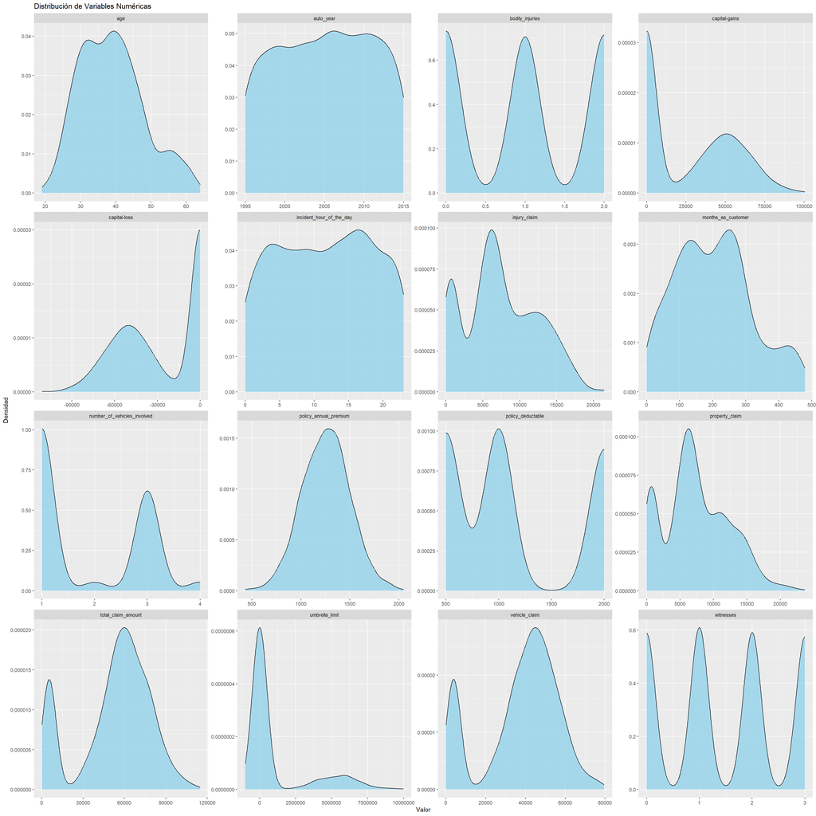

```r
p1<- variables_numericas %>%  ggplot(aes(x = Valor)) +
geom_density(fill = "skyblue", alpha = 0.7) +
facet_wrap(~ Variable, nrow = 4, ncol = 4, scales = "free") +
labs(title = "Distribución de Variables Numéricas",
     x = "Valor",
     y = "Densidad")
p1
```

Para determinar los valores atípicos vamos a presentar los diagramas de cajas:

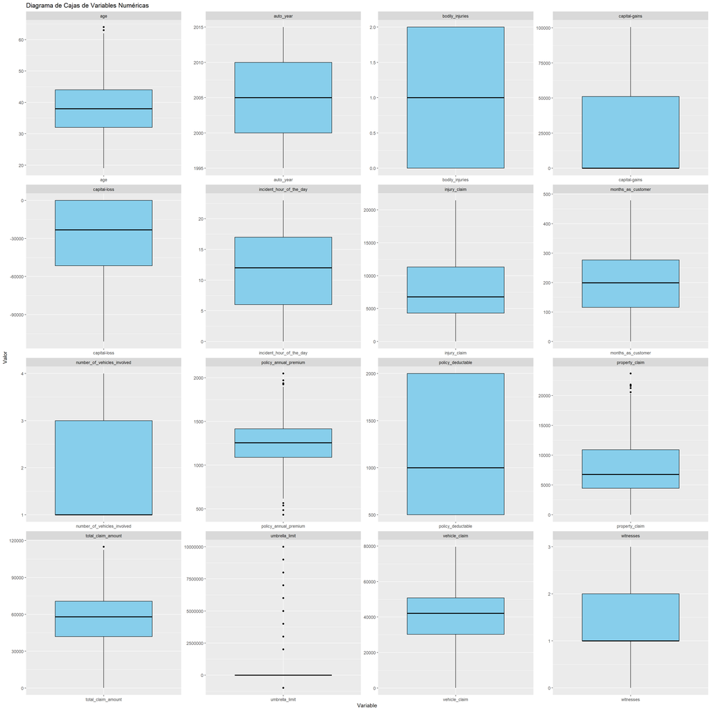

```r
p2<- variables_numericas %>% ggplot(aes(x = Variable, y = Valor)) +
  geom_boxplot(fill = "skyblue", color = "black") +
  facet_wrap(~ Variable, nrow = 4, ncol = 4, scales = "free") +
  labs(title = "Diagrama de Cajas de Variables Numéricas",
       x = "Variable",
       y = "Valor")
p2
```

Así, podemos notar que existen valores atípicos para las variables:

- age,
- policy_annual_premium,
- property_claim,
- total_claim_amount,
- umbrela_limit.

### Interpretación

El resto de variables se interpretan análogamente, nos vamos a centrar en el estudio de la variable **umbrella_limit**, pues se evidencian valores atípicos en el diagrama de cajas. El valor máximo de esta variable es $10000000$ y el valor mínimo es $-1000000$, además es el único valor negativo. El valor máximo no lo vamos a considerar como atípico, pues esta cobertura adicional es solicitada por personas con un alto patrimonio neto que poseen muchos activos o activos muy costosos. El valor negativo no es correcto, pues por definición esta cobertura no puede ser negativa, así, supondremos que este valor corresponde a un error, y lo vamos a considerar como positivo.

```r
insurance_claims<- insurance_claims %>% mutate(umbrella_limit = ifelse(umbrella_limit < 0, -1*umbrella_limit, umbrella_limit))
```

Finalmente, vamos a crear una variable considerando incident_date y policy_bind_date:

```r
insurance_claims<- insurance_claims %>%
                   mutate(num_anios = year(incident_date) - year(policy_bind_date)) %>%
                   select(-incident_date, -policy_bind_date)
```

Esta variable indicará el número de años trascurridos desde que se contrató la poliza y se realizó la reclamación.

Presentamos los estadísticos descriptivos de esta variable:

```r
summary(insurance_claims$num_anios)
```

```
##    Min. 1st Qu.  Median    Mean 3rd Qu.    Max.
##     0.0     7.0    13.0    13.4    20.0    25.0
```

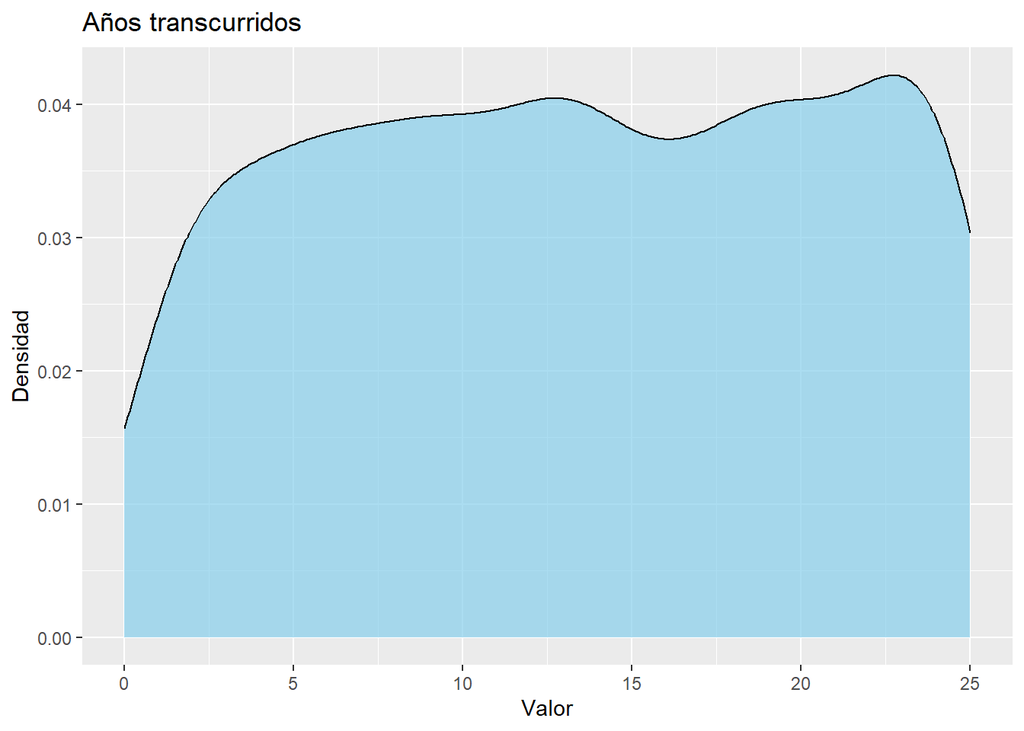

```r
ggplot(insurance_claims, aes(x = num_anios)) +
geom_density(fill = "skyblue", alpha = 0.7) +
labs(title = "Años transcurridos",
     x = "Valor",
     y = "Densidad")
```

Finalmente, vamos a presentar las correlaciones de las variables numéricas:

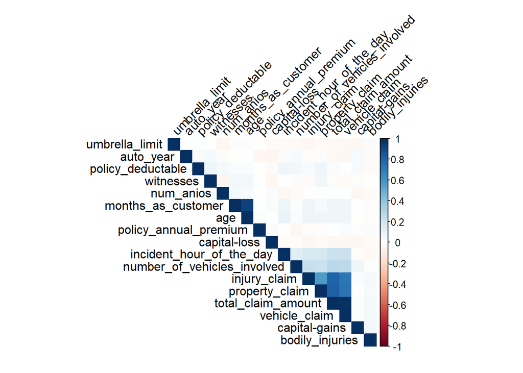

```r
correlation_matrix<- cor(insurance_claims %>% select_if(is.numeric))
corrplot(correlation_matrix, method = "color", type = "upper", order = "hclust", tl.col = "black", tl.srt = 45)
```

- Observamos una correlación alta entre las variables age y month age ($0.92$), algo lógico, pues a medida que aumenta la edad del asegurado también lo hará su tiempo como cliente.
- Además, la variable total_claim_amount posee un valor de correlación alto con respecto a las variables vehicle_claim, property_claim y injury_claim, siendo de $0.9827, 0.8107$ y $0.8050$, respectivamente. Esto se da, debido a que

$$total\_claim\_amount = vehicle\_claim +
property\_claim + injury\_claim.$$
Por ello, vamos a descartar a la variable total_claim_amount.

```r
insurance_claims<- insurance_claims %>% select(-total_claim_amount)
```

## Variables categóricas:

Calculemos el número de categorías distintas de cada variable:

```r
variables_categoricas <- select_if(insurance_claims, is.character) %>%
                         gather(key = "Variable", value = "Categoria")


num_categorias_por_variable <- sapply(select_if(insurance_claims, is.character), function(x) length(unique(x)))

num_categorias_por_variable
```

```
##            policy_state              policy_csl             insured_sex
##                       3                       3                       2
## insured_education_level      insured_occupation         insured_hobbies
##                       7                      14                      20
##    insured_relationship           incident_type          collision_type
##                       6                       4                       4
##       incident_severity   authorities_contacted          incident_state
##                       4                       5                       7
##           incident_city         property_damage police_report_available
##                       7                       3                       3
##               auto_make              auto_model          fraud_reported
##                      14                      39                       2
```

Las variables insured_occupation, insured_hobbie, auto_make y auto_model tienen varias categorías.

Presentemos la distribución de frecuencias de las variables que poseen hasta 5 categorías:

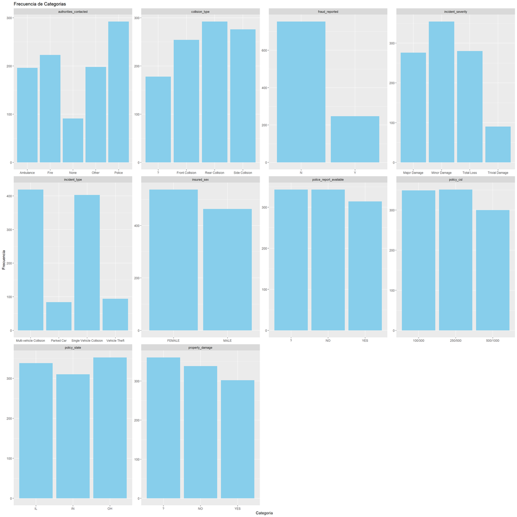

```r
variables<- names(num_categorias_por_variable[num_categorias_por_variable<6])

frecuencia_categorias <- count(variables_categoricas, Variable, Categoria)

p3<- frecuencia_categorias %>%
filter(Variable %in% variables) %>%
ggplot(aes(x = Categoria, y = n)) +
geom_bar(stat = "identity", fill = "skyblue") +
facet_wrap(~ Variable, nrow = 4, ncol = 4, scales = "free")  +
labs(title = "Frecuencia de Categorias",
     x = "Categoria",
     y = "Frecuencia")
p3
```

Podemos ver que para las variables collision_type, property_damage y police_report_available tenemos la categoría “?” que es un indicador de un valor perdido.

Vamos a reemplazar el valor de “?” por NoDefinido:

```r
insurance_claims<- insurance_claims %>% mutate(
    collision_type = ifelse(collision_type == "?", "NoDefinido", collision_type),
    property_damage = ifelse(property_damage == "?", "NoDefinido", property_damage),
    police_report_available = ifelse(police_report_available == "?", "NoDefinido", police_report_available)
)
```

También, presentamos la frecuencia relativa de cada variable:

```r
frecuencia_categorias %>% left_join(frecuencia_categorias %>%
                                      group_by(Variable) %>%
                                      summarise(total = sum(n)),
                                    by = c("Variable")) %>%
                          mutate(FreqRelativa = round(100*n/total,2) ) %>%
                          DT::datatable()
```

|  | Variable | Categoria | n | total | FreqRelativa |
| --- | --- | --- | --- | --- | --- |
| 1 | authorities_contacted | Ambulance | 196 | 1000 | 19.6 |
| 2 | authorities_contacted | Fire | 223 | 1000 | 22.3 |
| 3 | authorities_contacted | None | 91 | 1000 | 9.1 |
| 4 | authorities_contacted | Other | 198 | 1000 | 19.8 |
| 5 | authorities_contacted | Police | 292 | 1000 | 29.2 |
| 6 | auto_make | Accura | 68 | 1000 | 6.8 |
| 7 | auto_make | Audi | 69 | 1000 | 6.9 |
| 8 | auto_make | BMW | 72 | 1000 | 7.2 |
| 9 | auto_make | Chevrolet | 76 | 1000 | 7.6 |
| 10 | auto_make | Dodge | 80 | 1000 | 8 |

[output cut: 137 more lines]

Recategoricemos la variable authorities_contacted, de la siguiente forma:

$$authorities\_contacted = \begin{cases}
1 \quad\text{si}\quad authorities\_contacted \in\{\text{Fire, Ambulance,
Other, Police}\} \\ 0 \quad \text{si}\quad authorities\_contacted = None
\end{cases}$$

Es decir, authorities_contacted indicará si se contactó a una autoridad o no.

```r
insurance_claims<- insurance_claims %>% mutate(authorities_contacted =
                                                 ifelse(authorities_contacted == "None", "No","Si"))
```

Además, vamos a descartar las variables insured_occupation, insured_hobbies, incident_state, incident_city, auto_make y auto_model que poseen categorías con una frecuencia menor al $5\%$.

```r
insurance_claims<- insurance_claims %>% select(-insured_occupation, -insured_hobbies,
                                               -incident_state, -incident_city,
                                               -auto_make, -auto_model)
```

Nos interesa describir la relación entre el fraude y cada una de las variables mencionadas anteriormente. Para ello, por un lado graficaremos mediante diagramas de barras la cantidad de reclamaciones fraudulentas y no, según el tipo de cada variable.

### fraud_reported vs policy_state

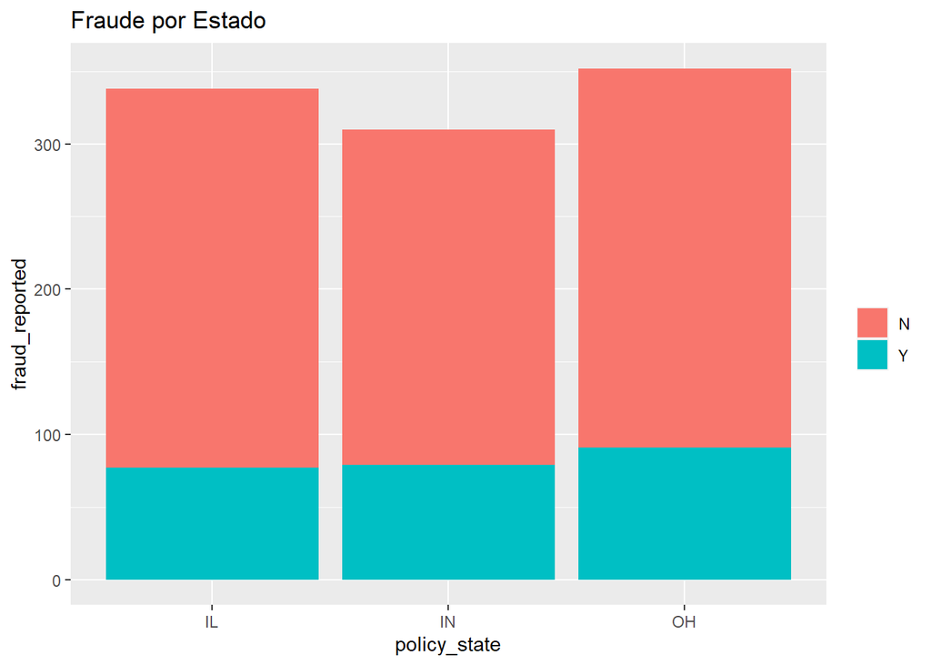

```r
plotby1<-ggplot(insurance_claims, aes(policy_state,fill=fraud_reported))+geom_bar() +labs(x="policy_state", y="fraud_reported")+ guides(fill=guide_legend(title="")) + ggtitle("Fraude por Estado")

plotby1
```

```r
prop.table(table(insurance_claims$policy_state, insurance_claims$fraud_reported), margin = 1)
```

```
##
##              N         Y
##   IL 0.7721893 0.2278107
##   IN 0.7451613 0.2548387
##   OH 0.7414773 0.2585227
```

Podemos ver que la proporción de reclamaciones no fraudulentas es similar en cada estado. El $77.22%, 74.52%$ y el $74.15%$ de las polizas emitidas en IL, IN y OH, respectivamente, no resultaron en una reclamación de fraude.

### fraud_reported vs policy_csl

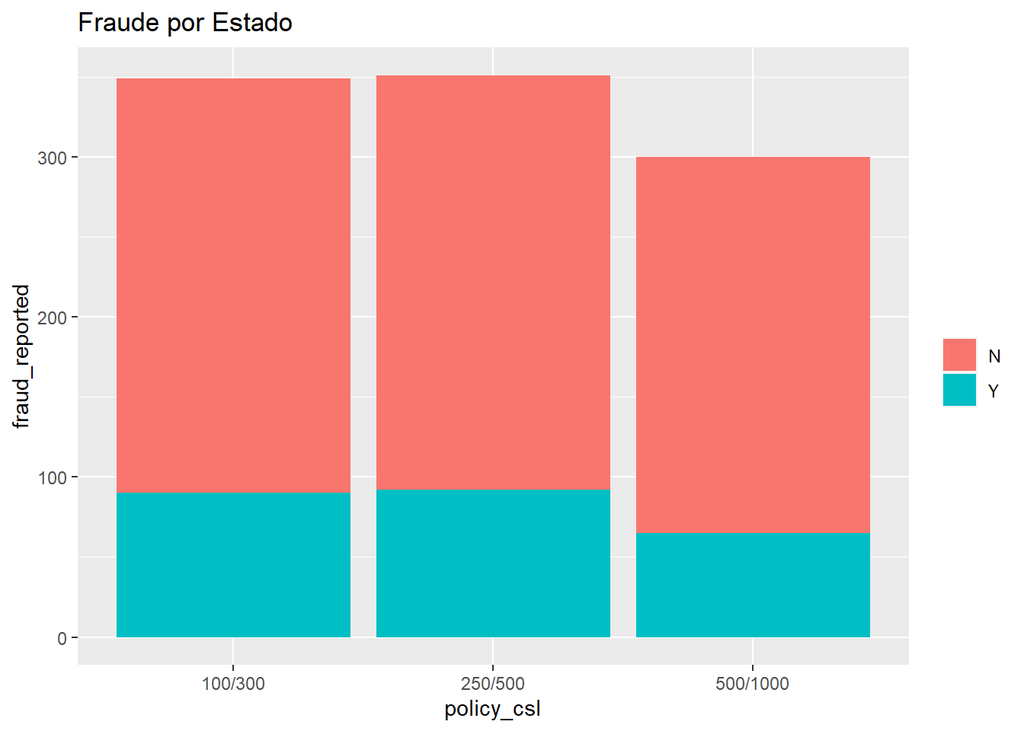

```r
plotby2<-ggplot(insurance_claims, aes(policy_csl,fill=fraud_reported))+geom_bar() +labs(x="policy_csl", y="fraud_reported")+ guides(fill=guide_legend(title="")) + ggtitle("Fraude por Estado")

plotby2
```

```r
prop.table(table(insurance_claims$policy_csl, insurance_claims$fraud_reported), margin = 1)
```

```
##
##                    N         Y
##   100/300  0.7421203 0.2578797
##   250/500  0.7378917 0.2621083
##   500/1000 0.7833333 0.2166667
```

Podemos ver que la en cada categoría existe mayor proporción de reclamos no fraudulentos. Resaltamos que para el límite 500/1000 el 78.33% de los reclamos no han incurrido en fraude.

### fraud_reported vs insured_sex

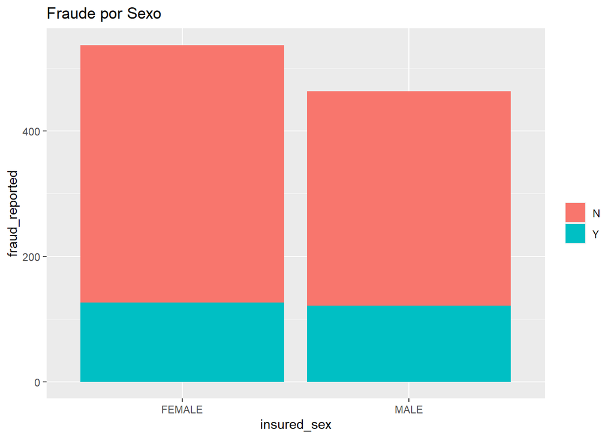

```r
plotby3<-ggplot(insurance_claims, aes(insured_sex,fill=fraud_reported))+geom_bar() +labs(x="insured_sex", y="fraud_reported")+ guides(fill=guide_legend(title="")) + ggtitle("Fraude por Sexo")

plotby3
```

```r
prop.table(table(insurance_claims$insured_sex, insurance_claims$fraud_reported), margin = 1)
```

```
##
##                  N         Y
##   FEMALE 0.7653631 0.2346369
##   MALE   0.7386609 0.2613391
```

### fraud_reported vs insured_education_level

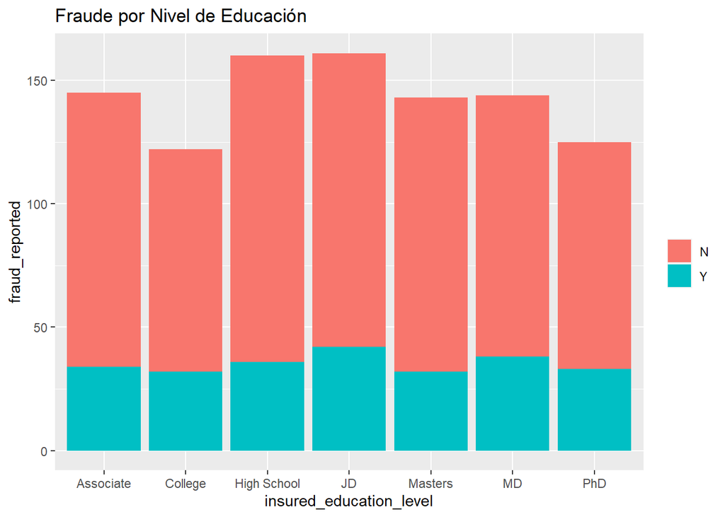

```r
plotby4<-ggplot(insurance_claims, aes(insured_education_level,fill=fraud_reported))+geom_bar() +labs(x="insured_education_level", y="fraud_reported")+ guides(fill=guide_legend(title="")) + ggtitle("Fraude por Nivel de Educación")

plotby4
```

```r
prop.table(table(insurance_claims$insured_education_level, insurance_claims$fraud_reported), margin = 1)
```

```
##
##                       N         Y
##   Associate   0.7655172 0.2344828
##   College     0.7377049 0.2622951
##   High School 0.7750000 0.2250000
##   JD          0.7391304 0.2608696
##   Masters     0.7762238 0.2237762
##   MD          0.7361111 0.2638889
##   PhD         0.7360000 0.2640000
```

La tasa de fraude es menor en todas las categorías de nivel de educación del asegurado. El $77.5%$ de los asegurados que han aprobado **High School** han realizado reclamaciones legítimas.

### fraud_reported vs insured_relationship

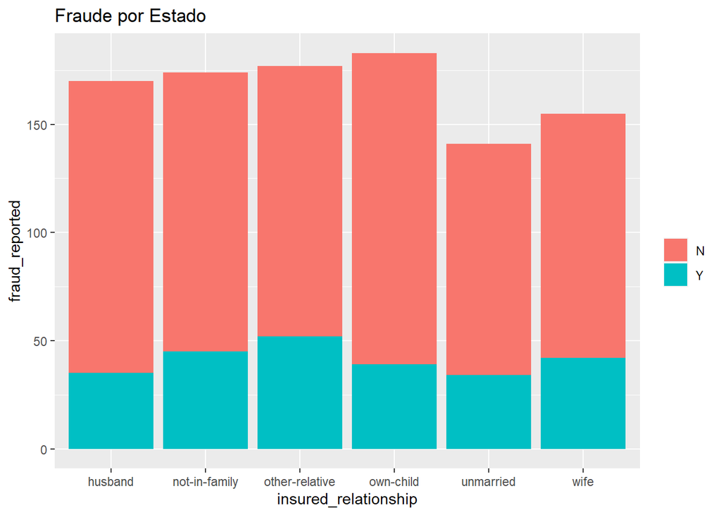

```r
plotby4<-ggplot(insurance_claims, aes(insured_relationship,fill=fraud_reported))+geom_bar() +labs(x="insured_relationship", y="fraud_reported")+ guides(fill=guide_legend(title="")) + ggtitle("Fraude por Estado")

plotby4
```

```r
prop.table(table(insurance_claims$insured_relationship, insurance_claims$fraud_reported), margin = 1)
```

```
##
##                          N         Y
##   husband        0.7941176 0.2058824
##   not-in-family  0.7413793 0.2586207
##   other-relative 0.7062147 0.2937853
##   own-child      0.7868852 0.2131148
##   unmarried      0.7588652 0.2411348
##   wife           0.7290323 0.2709677
```

El $79.41%$ de los asegurados casados presentaron un reclamo legítimo. Mientras que el $70.62%$ de los asegurados con otro tipo de relación realizaron un reclamo legítimo.

### fraud_reported vs incident_type

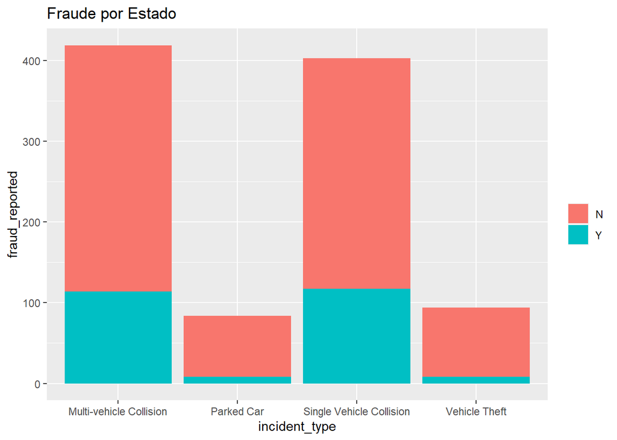

```r
plotby5<-ggplot(insurance_claims, aes(incident_type,fill=fraud_reported))+geom_bar() +labs(x="incident_type", y="fraud_reported")+ guides(fill=guide_legend(title="")) + ggtitle("Fraude por Estado")

plotby5
```

```r
prop.table(table(insurance_claims$incident_type, insurance_claims$fraud_reported), margin = 1)
```

```
##
##                                     N          Y
##   Multi-vehicle Collision  0.72792363 0.27207637
##   Parked Car               0.90476190 0.09523810
##   Single Vehicle Collision 0.70967742 0.29032258
##   Vehicle Theft            0.91489362 0.08510638
```

Si el incidente ocurrió cuando el vehículo estaba parqueado o robado, la tasa de fraude es baja. Por ejemplo, el $91.49%$ de las reclamaciones reportadas cuando robaron el vehículo fueron legítimas, análogamente para el $90.48%$ de reclamaciones reportadas cuando el vehículo estaba parqueado.

### fraud_reported vs collision_type

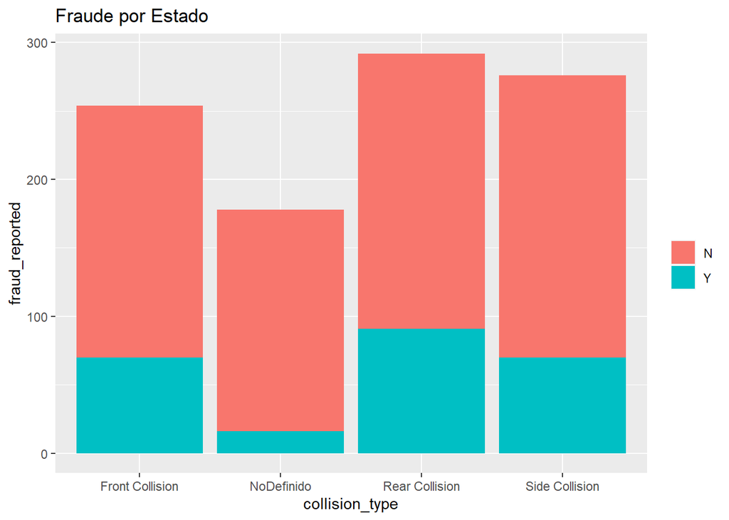

```r
plotby6<-ggplot(insurance_claims, aes(collision_type,fill=fraud_reported))+geom_bar() +labs(x="collision_type", y="fraud_reported")+ guides(fill=guide_legend(title="")) + ggtitle("Fraude por Estado")

plotby6
```

```r
prop.table(table(insurance_claims$collision_type, insurance_claims$fraud_reported), margin = 1)
```

```
##
##                            N          Y
##   Front Collision 0.72440945 0.27559055
##   NoDefinido      0.91011236 0.08988764
##   Rear Collision  0.68835616 0.31164384
##   Side Collision  0.74637681 0.25362319
```

Si no existe una colisión, entonces la proporción de reclamos no fraudelentos es alta.

Además, notemos que **NoDefinido** se presenta cuando el accidendet fue **Parked Car** o **Vehicle Theft**.

### fraud_reported vs incident_severity

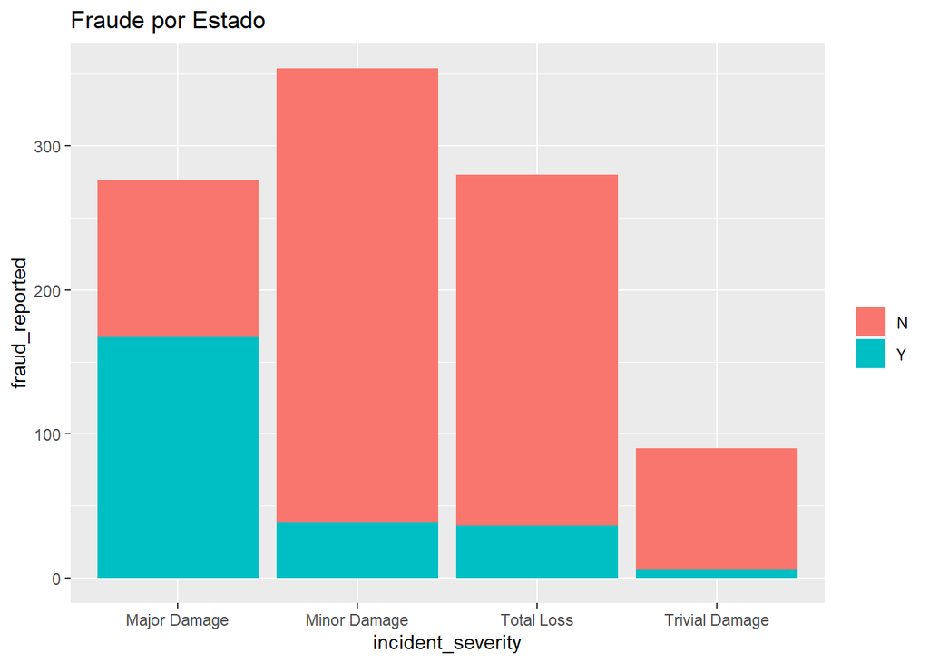

```r
plotby7<-ggplot(insurance_claims, aes(incident_severity,fill=fraud_reported))+geom_bar() +labs(x="incident_severity", y="fraud_reported")+ guides(fill=guide_legend(title="")) + ggtitle("Fraude por Estado")

plotby7
```

```r
prop.table(table(insurance_claims$incident_severity, insurance_claims$fraud_reported), margin = 1)
```

```
##
##                           N          Y
##   Major Damage   0.39492754 0.60507246
##   Minor Damage   0.89265537 0.10734463
##   Total Loss     0.87142857 0.12857143
##   Trivial Damage 0.93333333 0.06666667
```

Cuando el accidente fue con daños mayores, entonces el $60.51\%$ de los reclamos fueron fraudeulentos. Para el resto de categorías se mantienen proporciones altas para reclamaciones legítimas.

### fraud_reported vs authorities_contacted

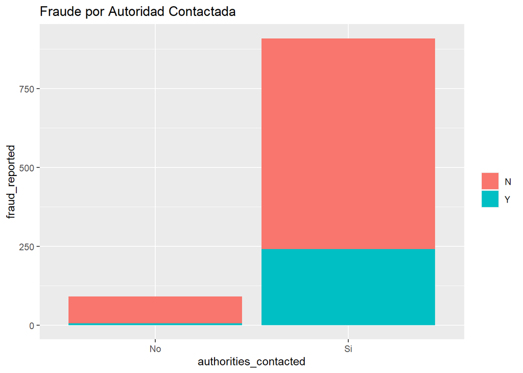

```r
plotby8<-ggplot(insurance_claims, aes(authorities_contacted,fill=fraud_reported))+geom_bar() +labs(x="authorities_contacted", y="fraud_reported")+ guides(fill=guide_legend(title="")) + ggtitle("Fraude por Autoridad Contactada")

plotby8
```

```r
prop.table(table(insurance_claims$authorities_contacted, insurance_claims$fraud_reported), margin = 1)
```

```
##
##               N          Y
##   No 0.93406593 0.06593407
##   Si 0.73487349 0.26512651
```

### fraud_reported vs property_damage

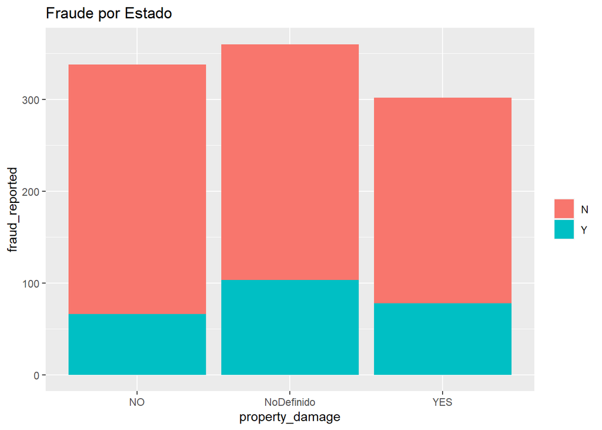

```r
plotby9<-ggplot(insurance_claims, aes(property_damage,fill=fraud_reported))+geom_bar() +labs(x="property_damage", y="fraud_reported")+ guides(fill=guide_legend(title="")) + ggtitle("Fraude por Estado")

plotby9
```

```r
prop.table(table(insurance_claims$property_damage, insurance_claims$fraud_reported), margin = 1)
```

```
##
##                      N         Y
##   NO         0.8047337 0.1952663
##   NoDefinido 0.7138889 0.2861111
##   YES        0.7417219 0.2582781
```

Cuando no existen daños a la propiedad externa como resultado del incidente o accidente, el $80.47/%$ de las reclamaciones son legítimas.

### fraud_reported vs police_report_available

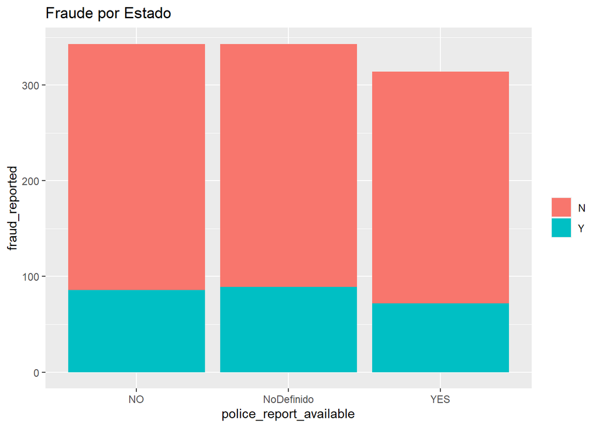

```r
plotby10<-ggplot(insurance_claims, aes(police_report_available,fill=fraud_reported))+geom_bar() +labs(x="police_report_available", y="fraud_reported")+ guides(fill=guide_legend(title="")) + ggtitle("Fraude por Estado")

plotby10
```

```r
prop.table(table(insurance_claims$police_report_available, insurance_claims$fraud_reported), margin = 1)
```

```
##
##                      N         Y
##   NO         0.7492711 0.2507289
##   NoDefinido 0.7405248 0.2594752
##   YES        0.7707006 0.2292994
```

La tasa de fraude es similar en todas las categorías. Por ejemplo, el $77.07%$ de los reclamos con informe policial sobre el incidente son legítimos.

# Selección de variables

## Variables categóricas

Con la intención de seleccionar aquellas variables categóricas que permitan describir de mejor manera los reclamos legítimos y los fraudulentos, vamos a emplear pruebas estadísticas que nos permitan analizar la capacidad predictiva de las mismas. Para ello, vamos a emplear la medida del valor de la información (IV).

El valor de la información (IV) es una medida de la capacidad predictiva de una variable categórica $x$ para predecir con precisión los casos positivos y los casos negativos. Según Siddiqi (2006), los valores del IV, indican lo siguiente:

- Menos de 0.02, entonces el predictor no es útil para el modelo.
- 0.02 a 0.1, entonces el predictor tiene solo una relación débil.
- 0.1 a 0.3, entonces el predictor tiene una relación de fuerza media.
- 0.3 o superior, entonces el predictor tiene una fuerte relación.
- Para calcular esta medida vamos a emplear la librería Information.

```r
library(Information)

insurance_claims<- insurance_claims %>% mutate_if(is.character, as.factor)

info_data<- create_infotables( insurance_claims %>% select_if(is.factor) %>% mutate(fraud_reported = ifelse( fraud_reported == "Y", 0, 1 ) ), y = "fraud_reported")

print(info_data$Summary)
```

```
##                   Variable          IV
## 8        incident_severity 1.361197444
## 7           collision_type 0.219321925
## 6            incident_type 0.209125918
## 9    authorities_contacted 0.144526277
## 10         property_damage 0.044602313
## 5     insured_relationship 0.029113745
## 2               policy_csl 0.011790844
## 4  insured_education_level 0.009155032
## 1             policy_state 0.005573345
## 3              insured_sex 0.005114816
## 11 police_report_available 0.004571561
```

De este modo, para entrenar el modelo solamente vamos a considerar aquellas variables para las cuales $IV>0.1$, es decir, **incident_severity**, **collision_type**, **incident_type**, **authorities_contacted**.

```r
seleccion_cat <- insurance_claims %>% select(incident_severity, collision_type,
                                             incident_type,
                                             authorities_contacted,
                                             fraud_reported)
```

## Variables numéricas

Para determinar las variables numéricas con mayor poder predictivo calcularemos el valor de Kolmogorov - Smirnov (KS) de las mismas con respecto a la variable **fraud_report** (variable dependiente). Así, vamos a comparar las distribuciones acumuladas empíricas del grupo de reclamos fraudulentos con el grupo de reclamos legítimos. De este modo, si su separación es mayor, entonces la distinción será mayor entre los grupos.

Para ello, creamos una función que nos permita calcular el valor del KS para cada variable numérica con respecto a la variable **fraud_report** y que nos retorne el p−valor:

```r
y<- ifelse(insurance_claims$fraud_reported == "Y",0,1 )

ks_test_func <- function(x) {
  ks_result <- ks.test(x  ~  y)
  return(ks_result$p.value)
}


ks_results <- sapply(insurance_claims %>% select_if(is.numeric), ks_test_func )

ks_results <- data.frame( VARIABLE = names(ks_results), p_valor = ks_results, row.names = NULL)

ks_results %>% arrange(p_valor)
```

```
##                       VARIABLE        p_valor
## 1                vehicle_claim 0.000000806003
## 2               property_claim 0.000022421168
## 3                 injury_claim 0.001752135381
## 4                    witnesses 0.397312291089
## 5  number_of_vehicles_involved 0.592912138650
## 6               umbrella_limit 0.611807899954
## 7           months_as_customer 0.657130971293
## 8     incident_hour_of_the_day 0.713369838950
## 9        policy_annual_premium 0.764812991330
## 10                   auto_year 0.858078902598
## 11             bodily_injuries 0.881874827740
## 12                capital-loss 0.921990983002
## 13               capital-gains 0.936565068306
## 14                         age 0.950364953419
## 15           policy_deductable 0.998759907216
## 16                   num_anios 0.999594189873
```

Vamos a considerar solamente aquellas variables para las cuales $p−valor<0.05$, pues esto implicaría que las distribuciones de cada variable con respecto a la variable *fraud_report* son distintas, es decir, las variables numéricas tienen poder predictivo. Por lo cual, las variables seleccionadas son:

```r
seleccion_num <- insurance_claims %>% select(vehicle_claim, property_claim,
                                             injury_claim)
```

### Selección del conjunto final

```r
datos_modelo<- cbind(seleccion_num, seleccion_cat)
names(datos_modelo)
```

```
## [1] "vehicle_claim"         "property_claim"        "injury_claim"
## [4] "incident_severity"     "collision_type"        "incident_type"
## [7] "authorities_contacted" "fraud_reported"
```

Por lo tanto, vamos a desarrollar el modelo empleando las variables:

- vehicle_claim,
- property_claim,
- injury_claim,
- incident_severity,
- collision_type,
- incident_type,
- authorities_contacted,
- fraud_reported.

# Modelos

Recordemos que la variable $fraud\_reported$ toma los valores de **N** y **Y**, así, vamos a transformarla de modo que tome los valores de 0 y 1, es decir:

$$fraud\_reported = \begin{cases} 0 \quad
& \text{si el reclamo es legítimo,} \\
1 \quad & \text{en caso contrario.} \end{cases}$$

```r
datos_modelo<- datos_modelo %>%
                   mutate(fraud_reported = ifelse(fraud_reported == "N", 0, 1))
```

Vamos a usar la librería *fastDummies* para transformar las variables categóricas a dummy’s:

```r
variables_cat <- c("incident_severity", "collision_type", "incident_type", "authorities_contacted")

datos_modelo_log <- dummy_cols(datos_modelo, select_columns = variables_cat, remove_selected_columns = TRUE  )
```

Previo a construir el modelo vamos a dividir el conjunto de datos, de modo que el 80% corresponda a la muestra de entrenamiento, y el 20% a la muestra de test

```r
# Fijamos el semillero:
set.seed(1234)
indice <- createDataPartition(datos_modelo_log$fraud_reported, p = 0.8, list=FALSE)
# Dividimos el conjunto:
entrenamiento <- datos_modelo_log[indice,]
test <- datos_modelo_log[-indice,]
```

Así, aplicamos el modelo de regresión logística:

```r
modelo_regresion <-glm(fraud_reported~., data = entrenamiento, family='binomial')
summary(modelo_regresion)
```

```
##
## Call:
## glm(formula = fraud_reported ~ ., family = "binomial", data = entrenamiento)
##
## Deviance Residuals:
##     Min       1Q   Median       3Q      Max
## -1.7401  -0.5639  -0.4453  -0.1802   2.8448
##
## Coefficients: (5 not defined because of singularities)
##                                              Estimate   Std. Error z value
## (Intercept)                              -4.459168746  0.974818982  -4.574
## vehicle_claim                             0.000018789  0.000010975   1.712
## property_claim                           -0.000008532  0.000027483  -0.310
## injury_claim                             -0.000031780  0.000027170  -1.170
## `incident_severity_Major Damage`          4.255456407  0.850716297   5.002
## `incident_severity_Minor Damage`          1.673045253  0.808039519   2.070
## `incident_severity_Total Loss`            1.973611430  0.860604507   2.293
## `incident_severity_Trivial Damage`                 NA           NA      NA
## `collision_type_Front Collision`          0.000796986  0.258335013   0.003
## collision_type_NoDefinido                 1.125975622  0.731624756   1.539
## `collision_type_Rear Collision`           0.547508747  0.246978565   2.217
## `collision_type_Side Collision`                    NA           NA      NA
## `incident_type_Multi-vehicle Collision`  -0.090146420  0.204677951  -0.440
## `incident_type_Parked Car`               -0.060167147  0.648806274  -0.093
## `incident_type_Single Vehicle Collision`           NA           NA      NA
## `incident_type_Vehicle Theft`                      NA           NA      NA
## authorities_contacted_No                 -0.750338091  0.670568226  -1.119
## authorities_contacted_Si                           NA           NA      NA
##                                             Pr(>|z|)
## (Intercept)                              0.000004777 ***
## vehicle_claim                                 0.0869 .
## property_claim                                0.7562
## injury_claim                                  0.2421
## `incident_severity_Major Damage`         0.000000567 ***
## `incident_severity_Minor Damage`              0.0384 *
## `incident_severity_Total Loss`                0.0218 *
## `incident_severity_Trivial Damage`                NA
## `collision_type_Front Collision`              0.9975
## collision_type_NoDefinido                     0.1238
## `collision_type_Rear Collision`               0.0266 *
## `collision_type_Side Collision`                   NA
## `incident_type_Multi-vehicle Collision`       0.6596
## `incident_type_Parked Car`                    0.9261
## `incident_type_Single Vehicle Collision`          NA
## `incident_type_Vehicle Theft`                     NA
## authorities_contacted_No                      0.2632
## authorities_contacted_Si                          NA
## ---
## Signif. codes:  0 '***' 0.001 '**' 0.01 '*' 0.05 '.' 0.1 ' ' 1
##
## (Dispersion parameter for binomial family taken to be 1)
##
##     Null deviance: 895.32  on 799  degrees of freedom
## Residual deviance: 681.99  on 787  degrees of freedom
## AIC: 707.99
##
## Number of Fisher Scoring iterations: 6
```

Podemos ver que existen variables no significativas cuyo p-valor es mayor a 0.05, además, variables sobre las que no se ha podido calcular los coeficientes. Por ello, es necesario estimar un nuevo modelo, para ello, vamos a aplicar el método de selección Backward.

```r
step(modelo_regresion, direction = "backward")
```

```
## Start:  AIC=707.99
## fraud_reported ~ vehicle_claim + property_claim + injury_claim +
##     `incident_severity_Major Damage` + `incident_severity_Minor Damage` +
##     `incident_severity_Total Loss` + `incident_severity_Trivial Damage` +
##     `collision_type_Front Collision` + collision_type_NoDefinido +
##     `collision_type_Rear Collision` + `collision_type_Side Collision` +
##     `incident_type_Multi-vehicle Collision` + `incident_type_Parked Car` +
##     `incident_type_Single Vehicle Collision` + `incident_type_Vehicle Theft` +
##     authorities_contacted_No + authorities_contacted_Si
##
##
## Step:  AIC=707.99
## fraud_reported ~ vehicle_claim + property_claim + injury_claim +
##     `incident_severity_Major Damage` + `incident_severity_Minor Damage` +
##     `incident_severity_Total Loss` + `incident_severity_Trivial Damage` +
##     `collision_type_Front Collision` + collision_type_NoDefinido +
##     `collision_type_Rear Collision` + `collision_type_Side Collision` +
##     `incident_type_Multi-vehicle Collision` + `incident_type_Parked Car` +
##     `incident_type_Single Vehicle Collision` + `incident_type_Vehicle Theft` +
##     authorities_contacted_No
##
##
## Step:  AIC=707.99
## fraud_reported ~ vehicle_claim + property_claim + injury_claim +
##     `incident_severity_Major Damage` + `incident_severity_Minor Damage` +
##     `incident_severity_Total Loss` + `incident_severity_Trivial Damage` +
##     `collision_type_Front Collision` + collision_type_NoDefinido +
##     `collision_type_Rear Collision` + `collision_type_Side Collision` +
##     `incident_type_Multi-vehicle Collision` + `incident_type_Parked Car` +
##     `incident_type_Single Vehicle Collision` + authorities_contacted_No
##
##
## Step:  AIC=707.99
## fraud_reported ~ vehicle_claim + property_claim + injury_claim +
##     `incident_severity_Major Damage` + `incident_severity_Minor Damage` +
##     `incident_severity_Total Loss` + `incident_severity_Trivial Damage` +
##     `collision_type_Front Collision` + collision_type_NoDefinido +
##     `collision_type_Rear Collision` + `collision_type_Side Collision` +
##     `incident_type_Multi-vehicle Collision` + `incident_type_Parked Car` +
##     authorities_contacted_No
```

[output cut: 123 more lines]

```
## - `incident_severity_Major Damage`  1   716.18 730.18
##
## Step:  AIC=699.15
## fraud_reported ~ vehicle_claim + `incident_severity_Major Damage` +
##     `incident_severity_Minor Damage` + `incident_severity_Total Loss` +
##     collision_type_NoDefinido + `collision_type_Rear Collision`
##
##                                    Df Deviance    AIC
## <none>                                  685.15 699.15
## - vehicle_claim                     1   687.17 699.17
## - collision_type_NoDefinido         1   687.29 699.29
## - `incident_severity_Minor Damage`  1   690.02 702.02
## - `incident_severity_Total Loss`    1   691.15 703.15
## - `collision_type_Rear Collision`   1   691.79 703.79
## - `incident_severity_Major Damage`  1   717.80 729.80
```

```
##
## Call:  glm(formula = fraud_reported ~ vehicle_claim + `incident_severity_Major Damage` +
##     `incident_severity_Minor Damage` + `incident_severity_Total Loss` +
##     collision_type_NoDefinido + `collision_type_Rear Collision`,
##     family = "binomial", data = entrenamiento)
##
## Coefficients:
##                      (Intercept)                     vehicle_claim
##                       -4.4970767                         0.0000131
## `incident_severity_Major Damage`  `incident_severity_Minor Damage`
##                        4.1465380                         1.5621992
##   `incident_severity_Total Loss`         collision_type_NoDefinido
##                        1.8757803                         0.8754004
##  `collision_type_Rear Collision`
##                        0.5399996
##
## Degrees of Freedom: 799 Total (i.e. Null);  793 Residual
## Null Deviance:       895.3
## Residual Deviance: 685.1     AIC: 699.1
```

De este modo, el mejor modelo tiene un valor de $AIC = 699.1$.

```r
modelo_fin<- glm(formula = fraud_reported ~ vehicle_claim +
                   `incident_severity_Major Damage` +
                   #`incident_severity_Minor Damage` +
                   `incident_severity_Total Loss` +
                   collision_type_NoDefinido +
                   `collision_type_Rear Collision`,
    family = "binomial", data = entrenamiento)

summary(modelo_fin)
```

```
##
## Call:
## glm(formula = fraud_reported ~ vehicle_claim + `incident_severity_Major Damage` +
##     `incident_severity_Total Loss` + collision_type_NoDefinido +
##     `collision_type_Rear Collision`, family = "binomial", data = entrenamiento)
##
## Deviance Residuals:
##     Min       1Q   Median       3Q      Max
## -1.5856  -0.5379  -0.4304  -0.3744   2.2907
##
## Coefficients:
##                                      Estimate   Std. Error z value
## (Intercept)                      -2.934731293  0.508629363  -5.770
## vehicle_claim                     0.000013101  0.000009244   1.417
## `incident_severity_Major Damage`  2.584331236  0.264807800   9.759
## `incident_severity_Total Loss`    0.313575742  0.295787292   1.060
## collision_type_NoDefinido         0.353310054  0.570351681   0.619
## `collision_type_Rear Collision`   0.539993236  0.210091488   2.570
##                                              Pr(>|z|)
## (Intercept)                             0.00000000793 ***
## vehicle_claim                                  0.1564
## `incident_severity_Major Damage` < 0.0000000000000002 ***
## `incident_severity_Total Loss`                 0.2891
## collision_type_NoDefinido                      0.5356
## `collision_type_Rear Collision`                0.0102 *
## ---
## Signif. codes:  0 '***' 0.001 '**' 0.01 '*' 0.05 '.' 0.1 ' ' 1
##
## (Dispersion parameter for binomial family taken to be 1)
##
##     Null deviance: 895.32  on 799  degrees of freedom
## Residual deviance: 690.02  on 794  degrees of freedom
## AIC: 702.02
##
## Number of Fisher Scoring iterations: 5
```

Ahora, vamos a calcular los odd ratios:

```r
odds<- exp(coefficients(modelo_fin))
odds
```

```
##                      (Intercept)                    vehicle_claim
##                         0.053145                         1.000013
## `incident_severity_Major Damage`   `incident_severity_Total Loss`
##                        13.254422                         1.368309
##        collision_type_NoDefinido  `collision_type_Rear Collision`
##                         1.423773                         1.715995
```

La interpretación es la siguiente:

- **Intercepto**: Por el signo del coeficiente podemos asegurar que existen menos reclamaciones fraudulentas que legítimas.
- **vehicle claim**: La probabilidad de que una reclamación sea fraudulenta está positivamente relacionada con el monto del reclamo. Específicamente, el odds ratio es 1.00001310, lo cual indica que un aumento de una unidad en el monto del reclamo del vehículo se asocia con un aumento del 0.0013% en las probabilidades de que ocurra un fraude, cuando se mantienen el resto de variables constantes.
- **incident_severity:** En este caso, consideramos *Trivial Damage* y **Minor Damage** como categoría de referencia. De este modo, dado que el odds ratio de *incident_severity_Major Damage* es $13.25$, esto implica que, en comparación con los casos donde el incidente resultó en daños triviales o menores, los casos donde el incidente resultó en daños importantes tienen aproximadamente 13 veces mayores probabilidades de estar asociadas con un fraude, manteniendo todas las demás variables constantes.

Finalmente, para *incident_severity_Total Loss:* el odds ratio es $1.37$, lo cual establece que, en comparación con los casos donde el incidente resultó en daños triviales o menores, los casos donde el incidente resultó en pérdida total tienen aproximadamente 1.37 veces mayores probabilidades de estar asociadas con un reclamo fraudulento, cuando se mantiene el resto de variables constantes.

- **collision_type**:

Para la variable *collision_type_NoDefinido* el odds ratioes $1.42$, esto significa que, en comparación con los casos donde el tipo de colisión es “Front Collision” o “Side Collision” , los casos donde el tipo de colisión es “NoDefinido” tienen aproximadamente $1.42$ veces más probabilidades de estar asociados con un fraude, manteniendo todas las demás variables constantes.

Para *collision_type_Rear Collision* el odss ratio es $1.72$, lo cual implica que, en comparación con los casos donde el tipo de colisión es “Front Collision” o “Side Collision”, los casos donde el tipo de colisión es “Rear Collision” tienen aproximadamente 1.72 veces más probabilidades de estar asociados con un fraude, manteniendo todas las demás variables constantes.

### Bondad de ajuste:

Utilizaremos el test de Hosmer Lemeshow para determinar la bondad de ajuste del modelo, es decir, para evaluar si el modelo se ajusta bien a los datos.

```r
library(ResourceSelection)

hoslem.test(entrenamiento$fraud_reported,fitted.values(modelo_fin))
```

```
##
##  Hosmer and Lemeshow goodness of fit (GOF) test
##
## data:  entrenamiento$fraud_reported, fitted.values(modelo_fin)
## X-squared = 10.059, df = 8, p-value = 0.2609
```

De este modo, dado que $p-valor = 0.2609 > 0.05$, no rechazamos la hipótesis nula. Esto quiere decir que, existe evidencia estadística para afirmar que el modelo tiene un ajuste aceptable a los datos.

Ahora, vamos a estudiar la presencia de multicolinealidad entre las variables predictoras, para ello, vamos a calcular el Factor de la Varianza:

```r
car::vif(modelo_fin)
```

```
##                    vehicle_claim `incident_severity_Major Damage`
##                         2.390473                         1.897875
##   `incident_severity_Total Loss`        collision_type_NoDefinido
##                         1.746556                         3.002928
##  `collision_type_Rear Collision`
##                         1.088449
```

Podemos notar que obtenenos valores bajos para el VIF, por lo cual la mayoría de las variables son independientes o tienen una baja correlación entre sí (collision_type_NoDefinido ), por lo que los coeficientes estimandos en la regresión son correctos.

Para determinar el punto de corte y clasificar a las reclamaciones vamos a determinar la medida de Kolmogorov - Smirnov, de este, modo presentamos el gráfico de las distribuciones acumuladas de la razón de verdaderos positivos y la distribución de falsos positivos.

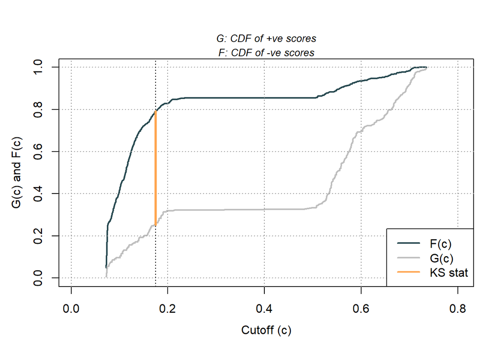

```r
library(ROCit)

dres <-data.frame(pred=predict(modelo_fin, entrenamiento, type="response"), var=entrenamiento$fraud_reported)

ROC <-rocit(score=dres$pred ,class=dres$var)

ksplot <-ksplot(ROC)
```

```r
cutoff <-ksplot$'KS Cutoff'

kstat <-as.numeric(ksplot$'KS stat')
```

Obtenemos un valor de $KS = 0.5398$, el cual se alcanza en $c = 0.1744$, el cual será nuestro punto de corte para clasificar entre reclamos fraudulentos y legítimos.

Vamos a calcular la matriz de confusión:

```r
predicciones <- predict(modelo_fin, newdata = entrenamiento, type = "response")

# Convertir las predicciones a clases (0 o 1)
predicciones_clases <- ifelse(predicciones > cutoff, 1, 0)

matriz_confusion <- confusionMatrix(table(predicciones_clases, entrenamiento$fraud_reported))
print(matriz_confusion)
```

```
## Confusion Matrix and Statistics
##
##
## predicciones_clases   0   1
##                   0 477  51
##                   1 125 147
##
##                Accuracy : 0.78
##                  95% CI : (0.7497, 0.8083)
##     No Information Rate : 0.7525
##     P-Value [Acc > NIR] : 0.03779
##
##                   Kappa : 0.4752
##
##  Mcnemar's Test P-Value : 0.00000003743
##
##             Sensitivity : 0.7924
##             Specificity : 0.7424
##          Pos Pred Value : 0.9034
##          Neg Pred Value : 0.5404
##              Prevalence : 0.7525
##          Detection Rate : 0.5962
##    Detection Prevalence : 0.6600
##       Balanced Accuracy : 0.7674
##
##        'Positive' Class : 0
##
```

- La exactitud del modelo es del 78%, lo que significa que el 78% de las predicciones del modelo son correctas.
- La sensibilidad del modelo es del 79.24%, lo que indica la proporción de casos positivos que el modelo predijo correctamente.
- La especificidad del modelo es del 74.24%, lo que indica la proporción de casos negativos que el modelo predijo correctamente.

Ahora, vamos a determinar la matriz de confusión para la muestra de test:

```r
predicciones <- predict(modelo_fin, newdata = test, type = "response")

# Convertir las predicciones a clases (0 o 1)
predicciones_clases <- ifelse(predicciones > cutoff, 1, 0)

matriz_confusion <- confusionMatrix(table(predicciones_clases, test$fraud_reported))
print(matriz_confusion)
```

```
## Confusion Matrix and Statistics
##
##
## predicciones_clases   0   1
##                   0 119  15
##                   1  32  34
##
##                Accuracy : 0.765
##                  95% CI : (0.7, 0.8219)
##     No Information Rate : 0.755
##     P-Value [Acc > NIR] : 0.4078
##
##                   Kappa : 0.4314
##
##  Mcnemar's Test P-Value : 0.0196
##
##             Sensitivity : 0.7881
##             Specificity : 0.6939
##          Pos Pred Value : 0.8881
##          Neg Pred Value : 0.5152
##              Prevalence : 0.7550
##          Detection Rate : 0.5950
##    Detection Prevalence : 0.6700
##       Balanced Accuracy : 0.7410
##
##        'Positive' Class : 0
##
```

- La exactitud del modelo en el conjunto de datos de prueba es del 76.5%, lo que significa que el 76.5% de las predicciones del modelo son correctas.
- La sensibilidad del modelo es del 78.8%, lo que indica la proporción de casos positivos que el modelo predijo correctamente en el conjunto de prueba.
- La especificidad del modelo es del 69.4%, lo que indica la proporción de casos negativos que el modelo predijo correctamente en el conjunto de prueba.

Así, comparando los valores de exactitud, sensibilidad y especificidad en la muestra de entrenamiento y validación, podemos determinar que el modelo generaliza a datos no vistos, es decir, no se evidencia un sobreajuste.

## Random Forest

```r
library(randomForest)

set.seed(1234)

datos_modelo<- datos_modelo %>% mutate(fraud_reported = as.factor(fraud_reported))

indice <- createDataPartition(datos_modelo$fraud_reported, p = 0.8, list=FALSE)
# Dividimos el conjunto:
entrenamiento <- datos_modelo[indice,]
test <- datos_modelo[-indice,]
```

Entrenamos el modelo:

```r
rf<- randomForest(fraud_reported ~ ., data = entrenamiento, ntree = 50)
rf
```

```
##
## Call:
##  randomForest(formula = fraud_reported ~ ., data = entrenamiento,      ntree = 50)
##                Type of random forest: classification
##                      Number of trees: 50
## No. of variables tried at each split: 2
##
##         OOB estimate of  error rate: 20.47%
## Confusion matrix:
##     0   1 class.error
## 0 536  67   0.1111111
## 1  97 101   0.4898990
```

Matriz de confusión para entrenamiento:

```r
predicciones_entrenamiento <- predict(rf, newdata = entrenamiento)

# Crear la matriz de confusión
matriz_confusion <- confusionMatrix(table(predicciones_entrenamiento,entrenamiento$fraud_reported))
print(matriz_confusion)
```

```
## Confusion Matrix and Statistics
##
##
## predicciones_entrenamiento   0   1
##                          0 591  29
##                          1  12 169
##
##                Accuracy : 0.9488
##                  95% CI : (0.9312, 0.963)
##     No Information Rate : 0.7528
##     P-Value [Acc > NIR] : < 0.0000000000000002
##
##                   Kappa : 0.8584
##
##  Mcnemar's Test P-Value : 0.01246
##
##             Sensitivity : 0.9801
##             Specificity : 0.8535
##          Pos Pred Value : 0.9532
##          Neg Pred Value : 0.9337
##              Prevalence : 0.7528
##          Detection Rate : 0.7378
##    Detection Prevalence : 0.7740
##       Balanced Accuracy : 0.9168
##
##        'Positive' Class : 0
##
```

Matriz de confusión para test:

```r
predicciones_test <- predict(rf, newdata = test)

# Crear la matriz de confusión
matriz_confusion <- confusionMatrix(table(predicciones_test,test$fraud_reported))
print(matriz_confusion)
```

```
## Confusion Matrix and Statistics
##
##
## predicciones_test   0   1
##                 0 133  32
##                 1  17  17
##
##                Accuracy : 0.7538
##                  95% CI : (0.6879, 0.8119)
##     No Information Rate : 0.7538
##     P-Value [Acc > NIR] : 0.5383
##
##                   Kappa : 0.2604
##
##  Mcnemar's Test P-Value : 0.0455
##
##             Sensitivity : 0.8867
##             Specificity : 0.3469
##          Pos Pred Value : 0.8061
##          Neg Pred Value : 0.5000
##              Prevalence : 0.7538
##          Detection Rate : 0.6683
##    Detection Prevalence : 0.8291
##       Balanced Accuracy : 0.6168
##
##        'Positive' Class : 0
##
```

Así, vamos a determinar los hiperparámetros óptimos para el Random Forest y el resto de modelos en el script posterior.

# Optimización de hiperparámetros

La optimización de hiperparámetros se realizó en Kaggle para aprovechar los procesadores GPU en el proceso de entrenamiento de los modelos. El código se encuentra en el script **02Hiperparametros.html**.

# Interpretación

El modelo empleado es el XGBoost, así, vamos a determinar los shap values:

```r
datosmodelo <- read_excel("datos/datosmodelo.xlsx")
datosmodelo<- datosmodelo %>% mutate(fraud_reported = as.factor(fraud_reported))

variables_cat <- c("incident_severity", "collision_type", "incident_type", "authorities_contacted")

datosmodelo <- dummy_cols(datosmodelo, select_columns = variables_cat, remove_selected_columns = TRUE  )

set.seed(1234)
indice <- createDataPartition(datosmodelo$fraud_reported, p = 0.8, list=FALSE)
entrenamiento <- datosmodelo[indice,]
test <- datosmodelo[-indice,]

X1 <- as.matrix(entrenamiento %>% select(-fraud_reported))

#Modelo final:
mod1<- xgboost::xgboost(
  data = X1, label = entrenamiento$fraud_reported, gamma = 0, eta = 0.01, max_depth = 3,
  colsample_bytree = 1, min_child_weight = 1, subsample = 1, nrounds = 100, verbose = FALSE, nthread = 1)

shap_values <- shap.values(xgb_model = mod1, X_train = X1)

shap_values$mean_shap_score
```

```
##         incident_severity_Major Damage                         property_claim
##                           0.1278526279                           0.0111828396
##                          vehicle_claim                           injury_claim
##                           0.0104697122                           0.0079571079
##          collision_type_Side Collision          collision_type_Rear Collision
##                           0.0066242981                           0.0031774813
## incident_type_Single Vehicle Collision  incident_type_Multi-vehicle Collision
##                           0.0013348921                           0.0003202343
##         incident_severity_Minor Damage           incident_severity_Total Loss
##                           0.0000000000                           0.0000000000
##       incident_severity_Trivial Damage         collision_type_Front Collision
##                           0.0000000000                           0.0000000000
##              collision_type_NoDefinido               incident_type_Parked Car
##                           0.0000000000                           0.0000000000
##            incident_type_Vehicle Theft               authorities_contacted_No
##                           0.0000000000                           0.0000000000
##               authorities_contacted_Si
##                           0.0000000000
```

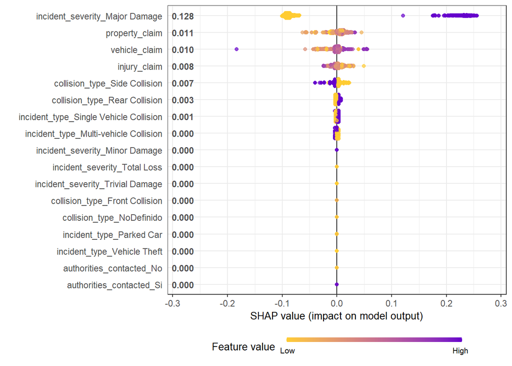

```r
shap_values_score <- shap_values$shap_score

shap_long <- shap.prep(xgb_model = mod1, X_train = X1)
shap_long <- shap.prep(shap_contrib = shap_values_score, X_train = X1)
shap.plot.summary(shap_long)
```

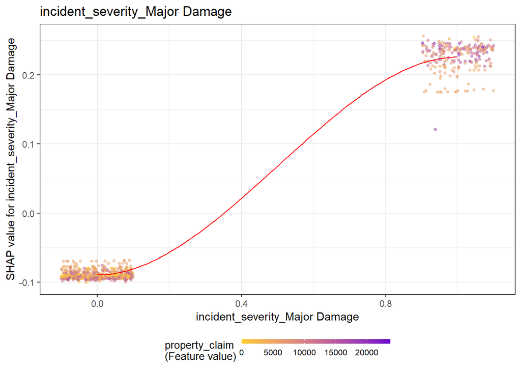

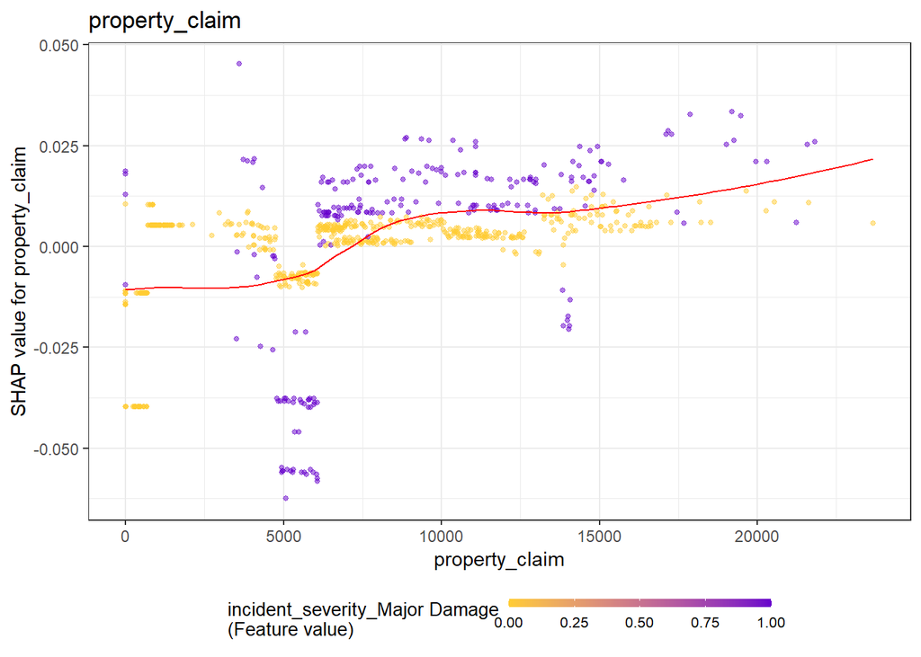

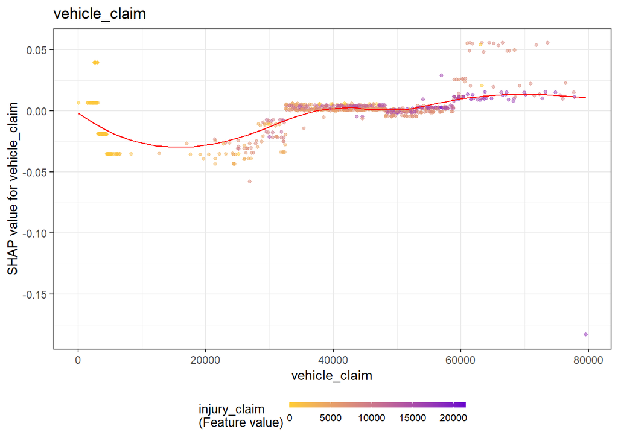

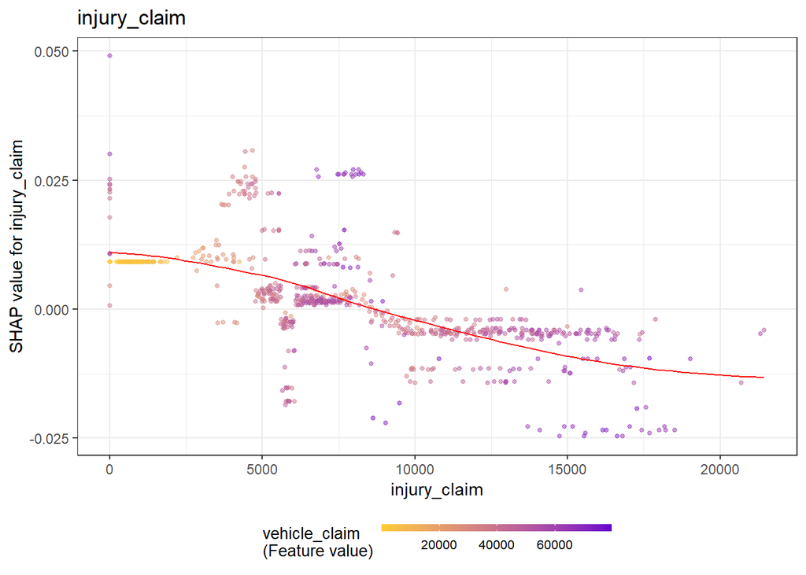

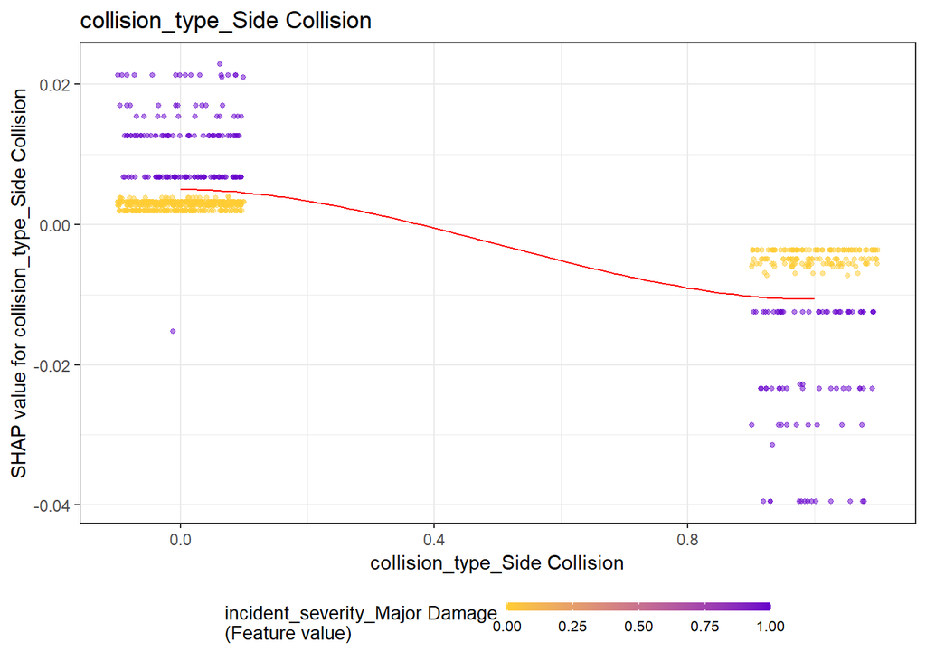

```r
for (v in shap.importance(shap_long, names_only = TRUE)[1:5]) {
  p <- shap.plot.dependence(shap_long, v, color_feature = "auto",
                            alpha = 0.5, jitter_width = 0.1) +
    ggtitle(v)
  print(p)
}
```